# Notes2, Exploratory Data Analysis

Linda Kukolich

January 14, 2015

# Week 2, Exploratory Dat Analysis

## Lattice Plots

Lecturer: Roger Peng, PhD

The lattice plotting system uses two packages, *lattice* and *grid*. Grid seems to be the overall layout system and we will not need to interact with it much.

- Lattice uses functions like `xyplot`, `bwplot`, and `levelplot`
- Lattice does plotting and annotation all in one call
- Lattice is particularly well suited to panel plots which divide the data by factors

Lattice Functions

- `xyplot` - this is the main function for creating scatter plots (vs `plot`)
  - `xyplot(y ~ x | f * g, data)`
  - *y-axis* ~ *x-axis*
  - f and g are optional conditioning variables
  - The * indicates an interaction between two variables)

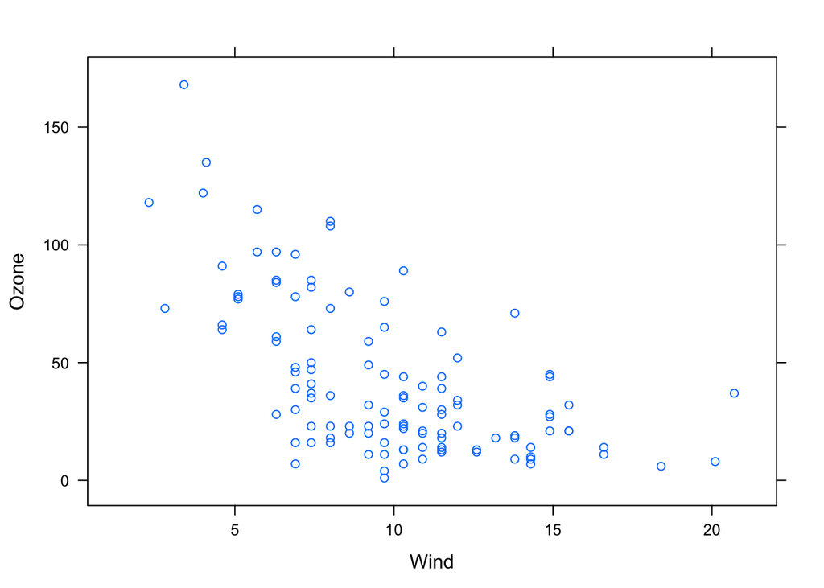

```r
library(lattice)
library(datasets)
xyplot(Ozone ~ Wind, data = airquality)
```

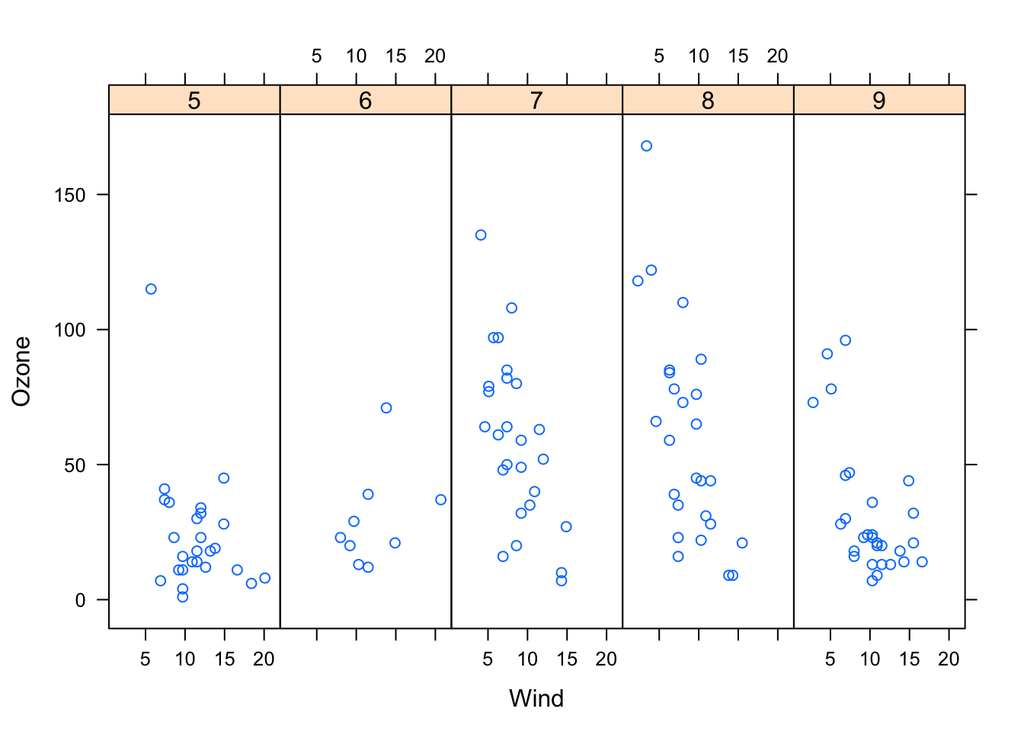

```r
# Convert Month to a factor variable
airquality <- transform(airquality, Month = factor(Month))
xyplot(Ozone ~ Wind | Month, data = airquality, layout = c(5, 1))
```

- `bwplot` - box and whiskers plots (vs `boxplot`)
- `histogram` (vs `hist`)
- `stripplot` - like a box plot but with actual points
- `dotplot` - plot dots on “violin strings”
- `splom` - ScatterPLOt Matrix (vs `pairs`)
- `levelplot`, `contourplot` - for plotting “image” data

Lattice Details * Lattice plots return a trellis object which will not display till the plot is printed

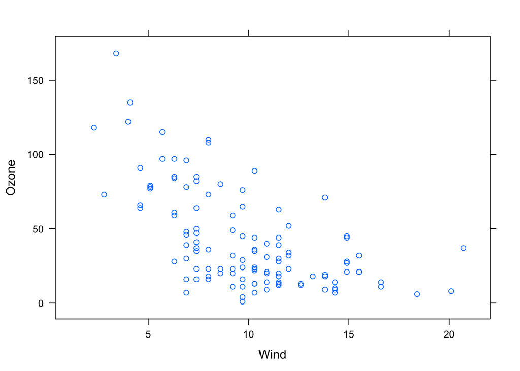

```r
p <- xyplot(Ozone ~ Wind, data = airquality) ## Nothing
print(p) ## plot appears
```

- panel function lets you set what happens in each plot. It seems to be the part after the |

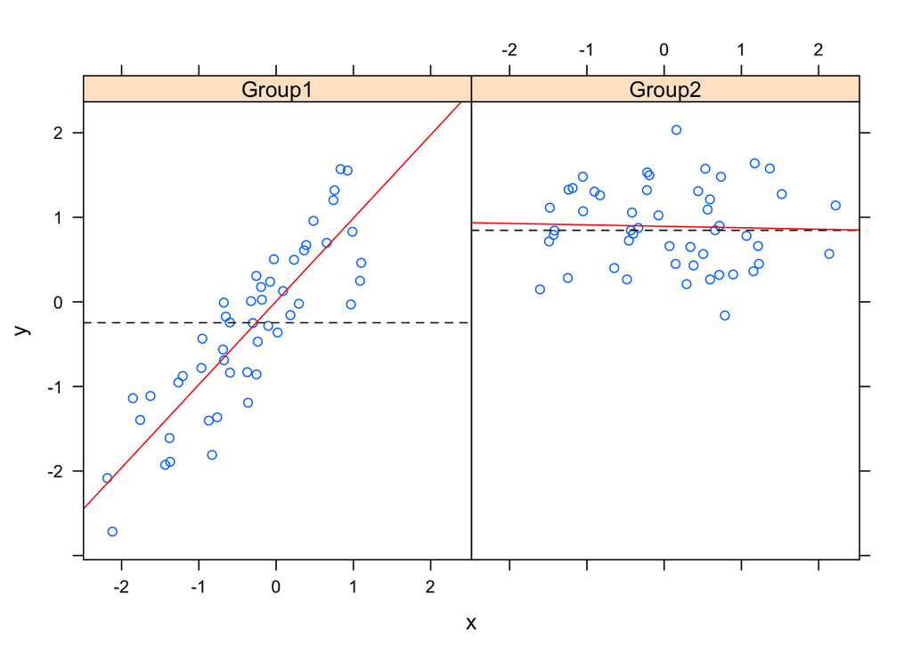

```r
# plot y vs x for Group 1 and Group 2
set.seed(10)
x <- rnorm(100)
f <- rep(0:1, each = 50)
y <- x + f - f * x + rnorm(100, sd = 0.5)
f <- factor(f, labels = c("Group1", "Group2"))
xyplot(y ~ x | f, panel = function(x, y, ...) {
  panel.xyplot(x, y, ...) ## First call the default panel function for xyplot
  panel.abline(h = median(y), lty = 2) ## Add a horizontal line at each median
  panel.lmline(x, y, col = 2) ## overlay a simple linear regression line
})
```

There can be many many plots. They give an example: How does indoor airborne mouse allergen vary over time and across subjects? Plotted visit number verses mouse allergen level plotted by subject, one Tiny plot per subject. Notice that some subjects are flat, some are missing data, some have variation.

## ggplot2

- ggplot2 is an implementation of Grammar of Graphics by Leland Wilkinson
- Written by Hadley Wickham while he was at Iowa State (Iowa State again)

> “In brief, the grammar tells us that a statistical graphic is a **mapping** from data to **aesthetic** attributes (colour, shape, size) of **geometric** objects (points, lines, bars). The plot may also contain statistical tranformations of the data and is drawn on a specific coordinate system” from *ggplot2* book

### `qplot()` - Quick Plot

- Works much like the `plot` function in the base graphics system
- Looks for data in a data frame, similar to lattice, or in the parent environment
- Data MUST be in a data.frame
- Plots are made up of *aesthetics* (size, shape, color) and *geoms* (points, lines)
- Factors are important for indicating subsets of the data (if they are to have different properties); they should be **labeled**
- Think “verb”, “noun”, “adjective” for graphics
- `qplot()` hides many details. Its defaults are okay for most operations
- `ggplot()` is the core function and very flexible for doing things qplot() cannot do

```r
library(ggplot2)
str(mpg) # a dataset included with ggplot2
```

```
## 'data.frame':    234 obs. of  11 variables:
##  $ manufacturer: Factor w/ 15 levels "audi","chevrolet",..: 1 1 1 1 1 1 1 1 1 1 ...
##  $ model       : Factor w/ 38 levels "4runner 4wd",..: 2 2 2 2 2 2 2 3 3 3 ...
##  $ displ       : num  1.8 1.8 2 2 2.8 2.8 3.1 1.8 1.8 2 ...
##  $ year        : int  1999 1999 2008 2008 1999 1999 2008 1999 1999 2008 ...
##  $ cyl         : int  4 4 4 4 6 6 6 4 4 4 ...
##  $ trans       : Factor w/ 10 levels "auto(av)","auto(l3)",..: 4 9 10 1 4 9 1 9 4 10 ...
##  $ drv         : Factor w/ 3 levels "4","f","r": 2 2 2 2 2 2 2 1 1 1 ...
##  $ cty         : int  18 21 20 21 16 18 18 18 16 20 ...
##  $ hwy         : int  29 29 31 30 26 26 27 26 25 28 ...
##  $ fl          : Factor w/ 5 levels "c","d","e","p",..: 4 4 4 4 4 4 4 4 4 4 ...
##  $ class       : Factor w/ 7 levels "2seater","compact",..: 2 2 2 2 2 2 2 2 2 2 ...
```

```
## geom_smooth: method="auto" and size of largest group is <1000, so using loess. Use 'method = x' to change the smoothing method.
```

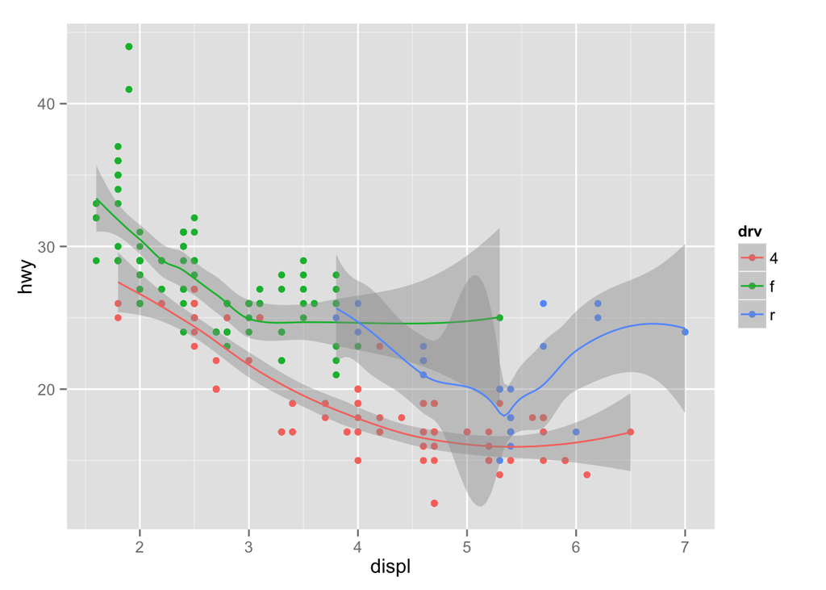

```r
# scatter plot with colors and added line
qplot(displ, hwy, data = mpg, color = drv, geom=c("point", "smooth"))
```

```
## stat_bin: binwidth defaulted to range/30. Use 'binwidth = x' to adjust this.
```

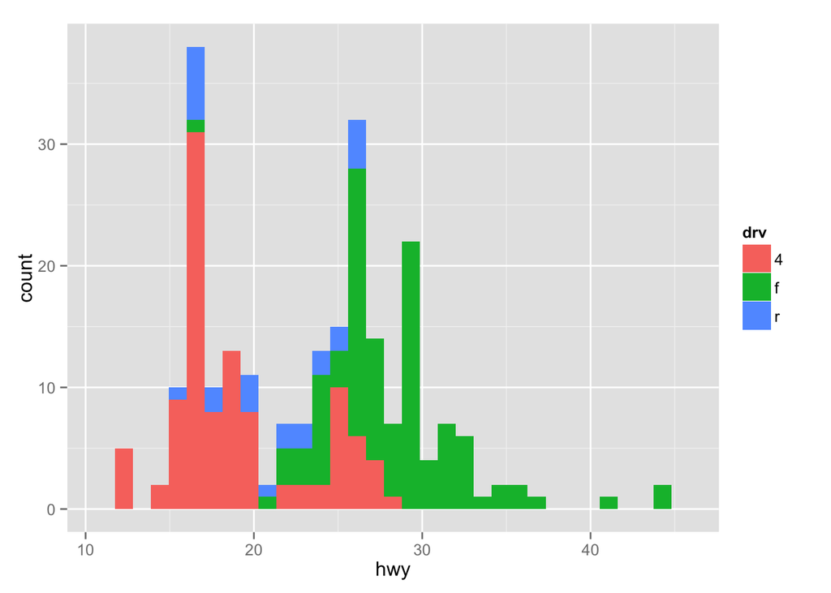

```r
# Histograms
qplot(hwy, data=mpg, fill = drv)
```

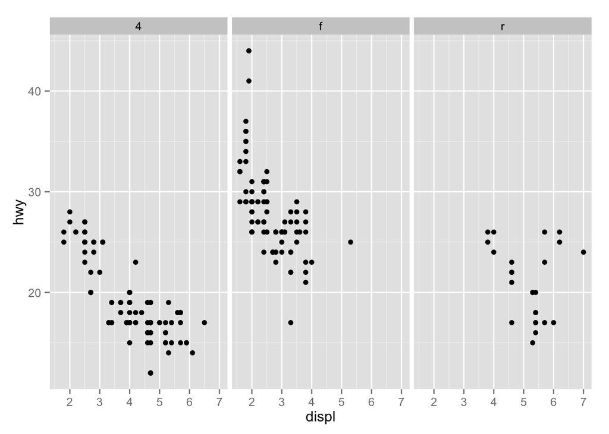

```r
# Facets
qplot(displ, hwy, data = mpg, facets = . ~ drv)
```

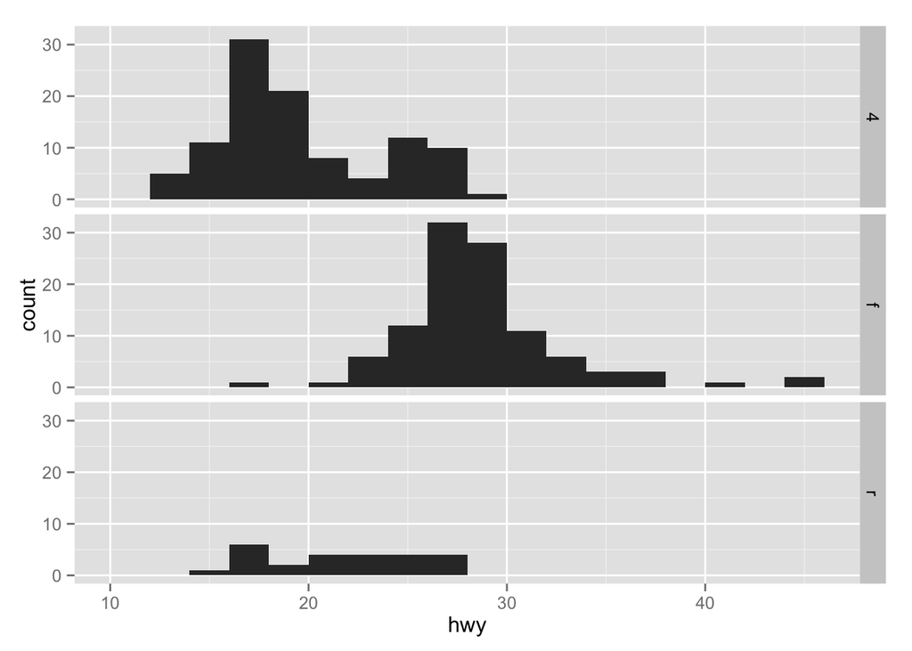

```r
qplot(hwy, data = mpg, facets = drv ~ ., binwidth = 2)
```

Some plots on the Mouse Allergen and Asthma Cohort Study data.

```
qplot(log(eno), data = maacs) # histogram of log of Exhaled nitric oxide
qplot(log(eno), data = maacs, fill = mopos) # same, but data are colored based on whether there is sensitivity to mouse allergen
qplot(log(eno), data = maacs, geom = "density") # smooth the histogram out to make a density plot
qplot(log(eno), data = maacs, geom = density, color = mppos)
# scatter plots eNO vs fine particulates
qplot(log(pm25), log(eno), data = maacs, shape = mopos) # but the shapes do not show well here
# switch to color points and add trend lines (linear regression)
qplot(log(pm25), log(eno), data = maacs, color = mopos, geom=c("point", "smooth"), method = "lm")
# make two separate plots
qplot(log(pm25), log(eno), data = maacs, geom = c("point", "smooth"), method = "lm", facets = . ~ mopos)
```

### Basic Components

- a **data frame**
- **aesthetic mappings**: how data are mapped to color and size
- **geoms**: geometric objects like points, lines, shapes
- **facets**: for conditional plots
- **stats**: statistical transformations like binning, quantiles, smoothing
- **scales**: what scale an aesthetic map uses (example: male=red, female=blue)
- **coordinate system**

### Building plots in ggplot

Plots are built up in layers.

- plot the data
- overlay a summary
- metadata and annotation

```
qplot(logpm25, NocturnalSympt, data = maacs, facets = . ~ bmicat, geom = c("pint", "smooth"), method = "lm")
# data
head(maacs)
g <- ggplot(maacs, aes(logpm25, NocturnalSympt))
            Data   Aesthetics
summary(g)
data: logpm25, bmicat, NocturnalSympt [554x3]
mapping: x = logpm25, y = NocturnalSympt
faceting: facet_null()
# another plot
g <- ggplot(maacs, aes(logpm25, NocturnalSympt))
print(g)
Error: No layers in plot
# save and print a plot
p <- g + geom_point()
print(p)
# just print it
g + geom_point()
# add overlays
g + geom_point() + geom_smooth()
g + geom_point() + geom_smooth(method="lm")
# Plus facets
g + geom_point() + facet_grid(. ~ bmicat) + geom_smooth(method="lm")
```

### Annotation

- Labels
  - xlab()
  - ylab()
  - labs()
  - ggtitle()
- Each of the “geom” functions has options to modify
- for global options, use theme `theme(legend.position = "non")`
- two standard appearance themes are included
  - theme_gray()
  - theme_bw()

### Modifying Aesthetics

```
# constant values
g + geom_point(color = "steelblue", size = 4, alpha = 1/2_)
# color based on data variable
g + geom_point(aes(color = bmicat), size = 4, alpha = 1/2)
# labels
g + geom_point(aes(color = bmicat), size = 4, alpha = 1/2) + labs(title = "MAACS Cohort") + labs(x = expression( log * PM[2.5]), y = "Nocturnal Symptoms")
# customizing the smooth
g + geom_point(aes(color = bmicat), size = 4, alpha = 1/2) + geom_smooth(size = 4, linetype = 3, method = "lm", se = FALSE)
# changing the Theme
g + geom_point(aes(color = bmicat)) + theme_bw(base_family =  = "Times")
# changing the axes
```

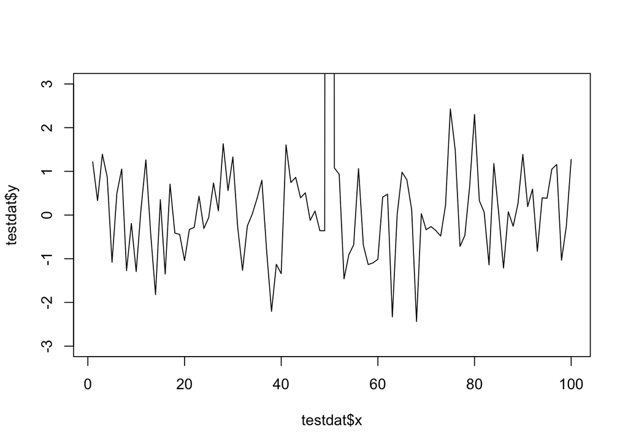

```r
testdat <- data.frame(x = 1:100, y = rnorm(100))
testdat[50,2] <- 100 ## Outlier!
plot(testdat$x, testdat$y, type = "l", ylim = c(-3, 3))
```

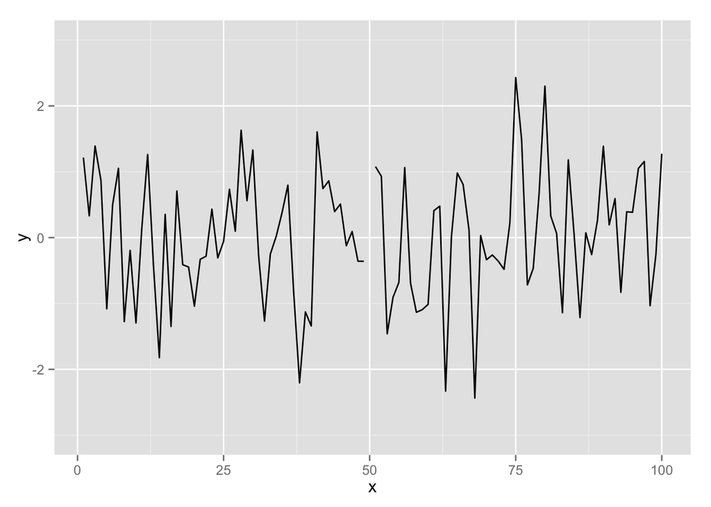

```r
# regular data hard to see
g <- ggplot(testdat, aes(x = x, y = y))
# outlier missing
g + geom_line() + ylim(-3, 3)
```

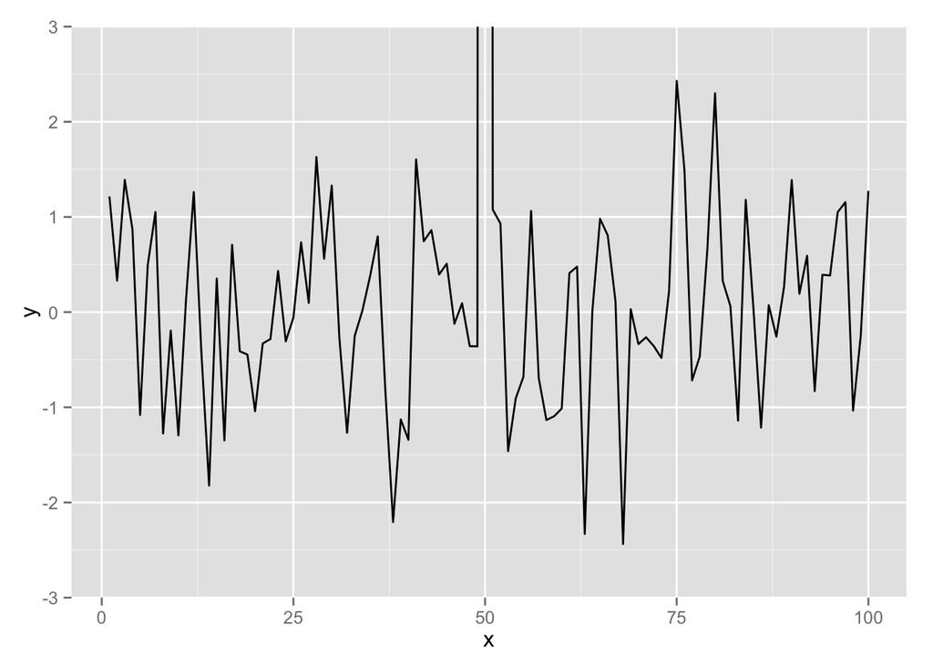

```r
# outlier included
g + geom_line() + coord_cartesian(ylim = c(-3, 3))
```